# Final Project: Is AIS an Effective Tool for Ships to Avoid Whale Watch Boat Aggregtions?

### Maximum Sample Size needed to obtain simulated Means

#### To determine optimal sample size for each predicted, simulated sample sizes were run against the mean for each predictor, as show in Figures 12-15. Optimal sample sizes ranged from 100-150 for each predictor.

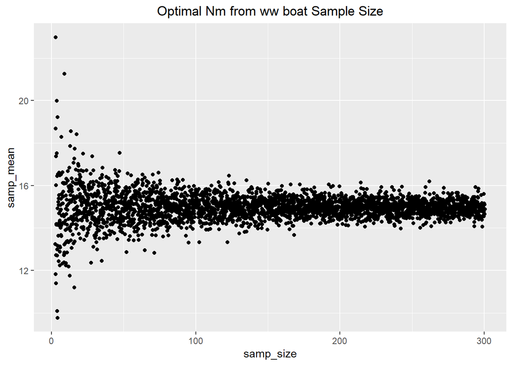

```r
###Nm_from_boat data

set.seed(2018)

samp_sim_nm <- data.frame(
  samp_size = rep(3:300, time = 10))  #I want a sample from 3 through 300, ten times

#take sample data frame
samp_sim_nm <- samp_sim_nm %>%
  #for each row (for each simulation)
  rowwise() %>%               #group by row and do something every row over and over again
  #draw a random normal sample with n = samp_size and take a mean
  mutate(samp_mean = mean(rnorm(samp_size, mean = mean_nm_Y, sd= sd_nm_Y)))

ggplot(data = samp_sim_nm,
       mapping = aes(x = samp_size, y = samp_mean)) +
  geom_jitter() +
  ggtitle("Optimal Nm from ww boat Sample Size") +
  theme(plot.title = element_text(hjust = 0.5))
```

```r
#take simulations
samp_sim_nm_summary <- samp_sim_nm %>%
  #for each sample size
  group_by(samp_size) %>%
  #calculate the SD of sample means
  summarize(sd_mean = sd(samp_mean)) %>%
  #order by SD
  arrange(sd_mean)
samp_sim_nm_summary
```

| samp_size | sd_mean |
| --- | --- |
| 297 | 0.1430909 |
| 280 | 0.1640393 |
| 191 | 0.1652766 |
| 205 | 0.1701827 |
| 149 | 0.1798704 |
| 289 | 0.1993473 |
| 261 | 0.1994216 |
| 153 | 0.2079748 |
| 264 | 0.2117593 |
| 101 | 0.2246985 |

[output cut: 288 more lines]

```r
#optimal sample size is about 100 for determining significant nm from the ww boat
```

##### Figure 12: Optimal Sample size for Nm_from_boat data. Optimal sample size is about 100 for a sample mean of 15.

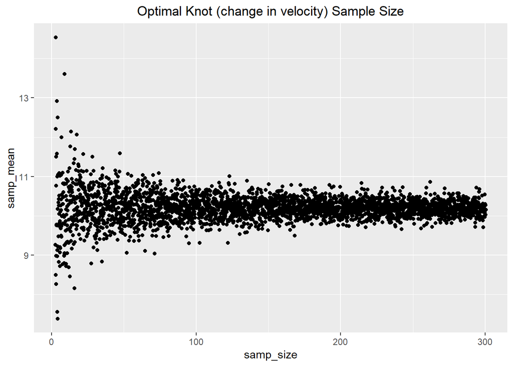

```r
###Knot data

set.seed(2018)

samp_sim_knots <- data.frame(
  samp_size = rep(3:300, time = 10))  #I want a sample from 3 through 300, ten times

#take sample data frame
samp_sim_knots <- samp_sim_knots %>%
  #for each row (for each simulation)
  rowwise() %>%               #group by row and do something every row over and over again
  #draw a random normal sample with n = samp_size and take a mean
  mutate(samp_mean = mean(rnorm(samp_size, mean = mean_knots_Y, sd= sd_knots_Y)))

ggplot(data = samp_sim_knots,
       mapping = aes(x = samp_size, y = samp_mean)) +
  geom_jitter() +
  ggtitle("Optimal Knot (change in velocity) Sample Size") +
  theme(plot.title = element_text(hjust = 0.5))
```

```r
#take simulations
samp_sim_knots_summary <- samp_sim_knots %>%
  #for each sample size
  group_by(samp_size) %>%
  #calculate the SD of sample means
  summarize(sd_mean = sd(samp_mean)) %>%
  #order by SD
  arrange(sd_mean)
samp_sim_knots_summary
```

| samp_size | sd_mean |
| --- | --- |
| 297 | 0.07751764 |
| 280 | 0.08886619 |
| 191 | 0.08953647 |
| 205 | 0.09219428 |
| 149 | 0.09744249 |
| 289 | 0.10799383 |
| 261 | 0.10803409 |
| 153 | 0.11266768 |
| 264 | 0.11471788 |
| 101 | 0.12172755 |

[output cut: 288 more lines]

```r
#optimal sample size is about 150
```

##### Figure 13: Optimal Sample size for change in velocity predictor data. Optimal sample size is about 150 for a sample mean of 10.

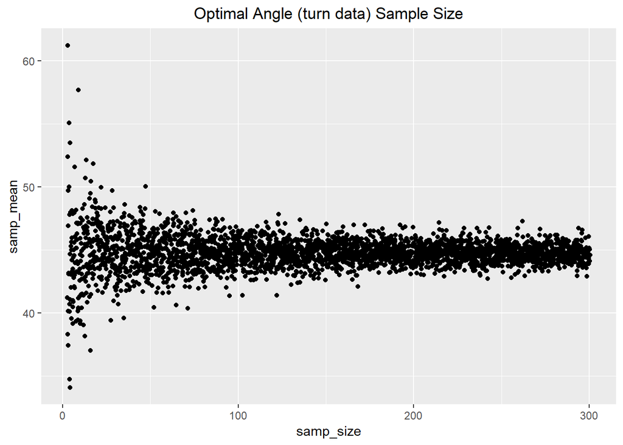

```r
###Angle data

set.seed(2018)

samp_sim_angle <- data.frame(
  samp_size = rep(3:300, time = 10))  #I want a sample from 3 through 300, ten times

#take sample data frame
samp_sim_angle <- samp_sim_angle %>%
  #for each row (for each simulation)
  rowwise() %>%               #group by row and do something every row over and over again
  #draw a random normal sample with n = samp_size and take a mean
  mutate(samp_mean = mean(rnorm(samp_size, mean = mean_angle_Y, sd= sd_angle_Y)))

ggplot(data = samp_sim_angle,
       mapping = aes(x = samp_size, y = samp_mean)) +
  geom_jitter() +
  ggtitle("Optimal Angle (turn data) Sample Size") +
  theme(plot.title = element_text(hjust = 0.5))
```

```r
#take simulations
samp_sim_angle_summary <- samp_sim_angle %>%
  #for each sample size
  group_by(samp_size) %>%
  #calculate the SD of sample means
  summarize(sd_mean = sd(samp_mean)) %>%
  #order by SD
  arrange(sd_mean)
samp_sim_angle_summary
```

| samp_size | sd_mean |
| --- | --- |
| 297 | 0.2935028 |
| 280 | 0.3364715 |
| 191 | 0.3390093 |
| 205 | 0.3490725 |
| 149 | 0.3689437 |
| 289 | 0.4088939 |
| 261 | 0.4090463 |
| 153 | 0.4265903 |
| 264 | 0.4343529 |
| 101 | 0.4608935 |

[output cut: 288 more lines]

```r
#optimal sample size is about 100
```

##### Figure 14: Optimal Sample size for Angle predictor data. Optimal sample size is about 100 for a sample mean of 45.

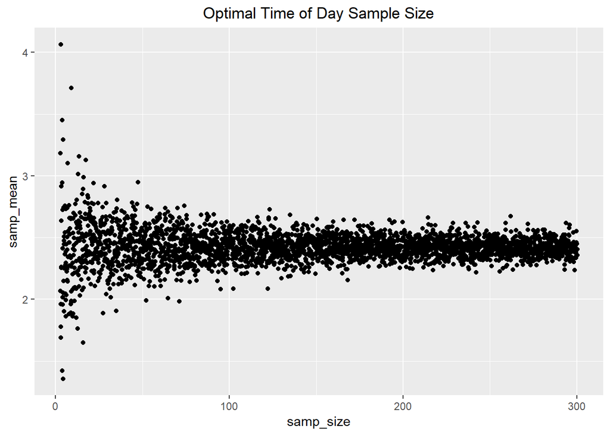

```r
###Angle data

set.seed(2018)

samp_sim_time <- data.frame(
  samp_size = rep(3:300, time = 10))  #I want a sample from 3 through 300, ten times


#take sample data frame
samp_sim_time <- samp_sim_time %>%
  #for each row (for each simulation)
  rowwise() %>%               #group by row and do something every row over and over again
  #draw a random normal sample with n = samp_size and take a mean
  mutate(samp_mean = mean(rnorm(samp_size, mean = mean_time_Y, sd= sd_time_Y)))

ggplot(data = samp_sim_time,
       mapping = aes(x = samp_size, y = samp_mean)) +
  geom_jitter() +
  ggtitle("Optimal Time of Day Sample Size") +
  theme(plot.title = element_text(hjust = 0.5))
```

```r
#take simulations
samp_sim_time_summary <- samp_sim_time %>%
  #for each sample size
  group_by(samp_size) %>%
  #calculate the SD of sample means
  summarize(sd_mean = sd(samp_mean)) %>%
  #order by SD
  arrange(sd_mean)
samp_sim_time_summary
```

| samp_size | sd_mean |
| --- | --- |
| 297 | 0.02932037 |
| 280 | 0.03361285 |
| 191 | 0.03386638 |
| 205 | 0.03487167 |
| 149 | 0.03685676 |
| 289 | 0.04084771 |
| 261 | 0.04086294 |
| 153 | 0.04261556 |
| 264 | 0.04339103 |
| 101 | 0.04604237 |

[output cut: 288 more lines]

```r
#optimal sample size is about 150
```

##### Figure 15: Optimal Sample size for Time predictor data. Optimal size is about 150 for a sample mean of 2.5.

### Power Analyses

#### Power analyses of the Welch two-sample t-tests were conducted in order to determine the minimal sample size needed to have low probability of a Type II error, or high power. The power threshold for this study was 0.80, as it is the conventional power threshold (Whitlock & Schluter 2015). Power analyses were performed on each predictor. Each analysis looked at how sample size effected power, by a factor of different standard deviations. Figure 16 results show that Nm_from_boat predictor would need a minimum sample size of 7 to obtain a power threshold of 0.80 (allowing a SD range of up to 8). Figure 17 results show that Knot predictor would need a minimum sample size of 43 to obtain a power threshold of 0.80 (allowing a SD range of up to 8). This higher needed sample size makes sense, as there was more simulated variation in this data. Figure 18 results show that Angle predictor would need a minimum sample size of 3 to obtain a power threshold of 0.80 (allowing a SD range of up to 8). Little variation was simulated in this predictor; hence a small sample size was expected. Lastly, in Figure 19, Time predictor will not obtain enough power, as there was no simulated difference between the control and experimental means.

```r
set.seed(2018)
###Nm_from_boat power

#simulate t data
#make a function data frame, that can repeat n amount of times
#use a normal distribution rnorm

make_t_data <- function(m1, m2, s, n){
  #make a data frame, repeating treatments n number of times
  #and use rnorm to get values
  data.frame(treatment = c(rep("A", n), rep("B", n)),
             value = rnorm(n*2, mean = c(rep(m1,n), rep(m2, n)), s))
}

#test if the fuction works
make_t_data(m1 = mean_nm_Y, m2 = mean_nm_N, s = sd_nm_Y, n = 100)
```

| treatment | value |
| --- | --- |
| A | 12.73616781 |
| A | 6.82538301 |
| A | 14.61685856 |
| A | 16.37562993 |
| A | 24.05671223 |
| A | 13.56634008 |
| A | 25.96694590 |
| A | 19.48325259 |
| A | 11.75215180 |
| A | 18.29628695 |

[output cut: 190 more lines]

```r
#the output of any t.test is a list with an entry called p.value
#so need to extract just a p-value

#extraction function:
get_p_from_t_test <- function(sim_data){
  #run the t test on the data
  test <- t.test(value ~ treatment, data = sim_data)
  test$p.value
}

#testing out extracton function:
get_p_from_t_test(make_t_data(m1 = mean_nm_Y, m2 = mean_nm_N, s = sd_nm_Y, n = 100))
```

```
## [1] 1.269181e-48
```

```r
#I get a small P value with big sample size
get_p_from_t_test(make_t_data(m1 = mean_nm_Y, m2 = mean_nm_N, s = sd_nm_Y, n = 3))
```

```
## [1] 0.01873539
```

```r
#I get a large P value the smaller the sample size I choose

#now I need to simulate p values many times
replicate(10,
          get_p_from_t_test(make_t_data(m1 = mean_nm_Y, m2 = mean_nm_N, s = sd_nm_Y, n = 100)))
```

```
##  [1] 1.302842e-43 3.051276e-47 2.195624e-47 7.031186e-46 5.299092e-42
##  [6] 1.923511e-49 4.252505e-60 1.186866e-44 8.483529e-47 5.777869e-49
```

```r
#10 P values created

#Now I need some number of simulations, and a set alpha (I will do .05)
get_t_power <- function(m1, m2, s, n, nsims = 100, alpha = 0.05){
  #a vector of p values
  p <- replicate(nsims,
                 get_p_from_t_test(make_t_data(m1, m2, s, n)))
  #calculate the number of p values that are incorrect given that we should be rejecting the null
  num_wrong <- sum(p > alpha)
  #return power
  1 - num_wrong/nsims
}

#test this function

#nm_from_boat Power
get_t_power(m1 = mean_nm_Y, m2 = mean_nm_N, s = sd_nm_Y, n = 100, nsims = 100, alpha=0.05)
```

```
## [1] 1
```

```r
#higher power with bigger sample size
get_t_power(m1 = mean_nm_Y, m2 = mean_nm_N, s = sd_nm_Y, n = 3, nsims = 100, alpha=0.05)
```

```
## [1] 0.57
```

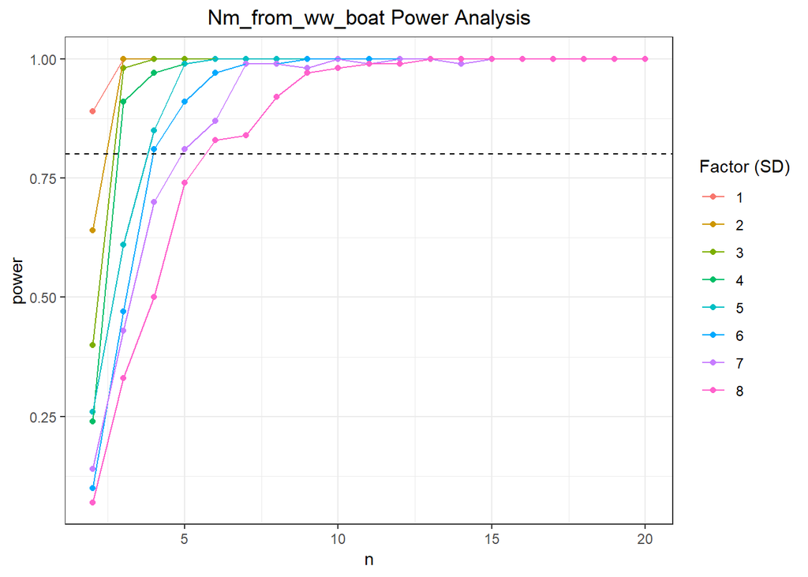

```r
#lower power with smaller sample size, does not reach 0.8

#get power from simulations
nm_power <- crossing(m1 = mean_nm_Y, m2 = mean_nm_N, s = 1:8, n = 2:20) %>%
  rowwise() %>%
  mutate(power = get_t_power(m1, m2, s, n, nsim = 100)) %>%
  ungroup()

ggplot(nm_power,
       mapping = aes(x = n, y = power, color = factor(s))) +
  geom_point() +
  geom_line() +
  theme_bw() +
  geom_hline(yintercept = 0.8, lty =2) +
  ggtitle("Nm_from_ww_boat Power Analysis") +
  theme(plot.title = element_text(hjust = 0.5)) +
  labs(colour = "Factor (SD)")
```

```r
#this shows that sample sizes of at least 7 will have enough power for nm_from_boat data, (with a SD ranging from 1:8)
```

##### Figure 16: Power analysis of Nm_from_boat data.This shows that sample size of at least 7 will have enough power to reach the threshold of 0.8, with SD’s ranging from 1:8.

```r
###Knot Power

#testing out extracton function:
get_p_from_t_test(make_t_data(m1 = mean_knots_Y, m2 = mean_knots_N, s = sd_knots_Y, n = 100))
```

```
## [1] 6.753678e-26
```

```r
#I get a small P value with big sample size
get_p_from_t_test(make_t_data(m1 = mean_knots_Y, m2 = mean_knots_N, s = sd_knots_Y, n = 3))
```

```
## [1] 0.07086268
```

```r
#I get a large P value the smaller the sample size I choose

#test the power function

#knot Power
get_t_power(m1 = mean_knots_Y, m2 = mean_knots_N, s = sd_knots_Y, n = 100, nsims = 100, alpha=0.05)
```

```
## [1] 1
```

```r
#higher power with bigger sample size
get_t_power(m1 = mean_knots_Y, m2 = mean_knots_N, s = sd_knots_Y, n = 3, nsims = 100, alpha=0.05)
```

```
## [1] 0.27
```

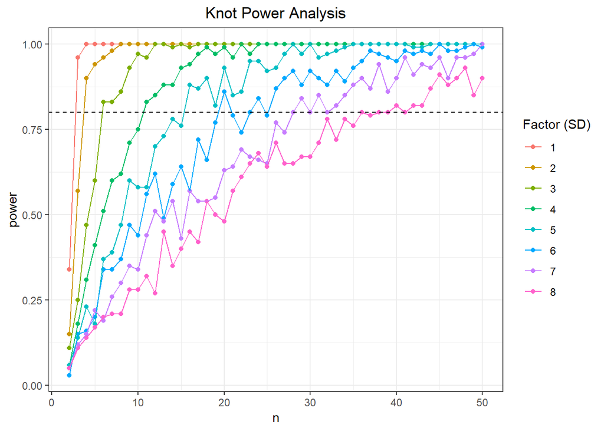

```r
#lower power with smaller sample size, does not reach 0.8

#get power from simulations
knot_power <- crossing(m1 = mean_knots_Y, m2 = mean_knots_N, s = 1:8, n = 2:50) %>%
  rowwise() %>%
  mutate(power = get_t_power(m1, m2, s, n, nsim = 100)) %>%
  ungroup()

ggplot(knot_power,
       mapping = aes(x = n, y = power, color = factor(s))) +
  geom_point() +
  geom_line() +
  theme_bw() +
  geom_hline(yintercept = 0.8, lty =2) +
  ggtitle("Knot Power Analysis") +
  theme(plot.title = element_text(hjust = 0.5)) +
  labs(colour = "Factor (SD)")
```

```r
#this shows that sample size of at least 43 to have enough power for knot_data(with a SD ranging from 1:8)
```

##### Figure 17: Power analysis of Knot data. This shows that sample size of at least 43 will have enough power to reach the threshold of 0.8, with SD’s ranging from 1:8.

```r
###Angle Power

#testing out extracton function:
get_p_from_t_test(make_t_data(m1 = mean_angle_Y, m2 = mean_angle_N, s = sd_angle_Y, n = 100))
```

```
## [1] 1.888688e-74
```

```r
#I get a small P value with big sample size
get_p_from_t_test(make_t_data(m1 = mean_angle_Y, m2 = mean_angle_N, s = sd_angle_Y, n = 3))
```

```
## [1] 0.007126051
```

```r
#I get a large P value the smaller the sample size I choose

#test the power function

#angle Power
get_t_power(m1 = mean_angle_Y, m2 = mean_angle_N, s = sd_angle_Y, n = 100, nsims = 100, alpha=0.05)
```

```
## [1] 1
```

```r
#higher power with bigger sample size
get_t_power(m1 = mean_angle_Y, m2 = mean_angle_N, s = sd_angle_Y, n = 3, nsims = 100, alpha=0.05)
```

```
## [1] 0.87
```

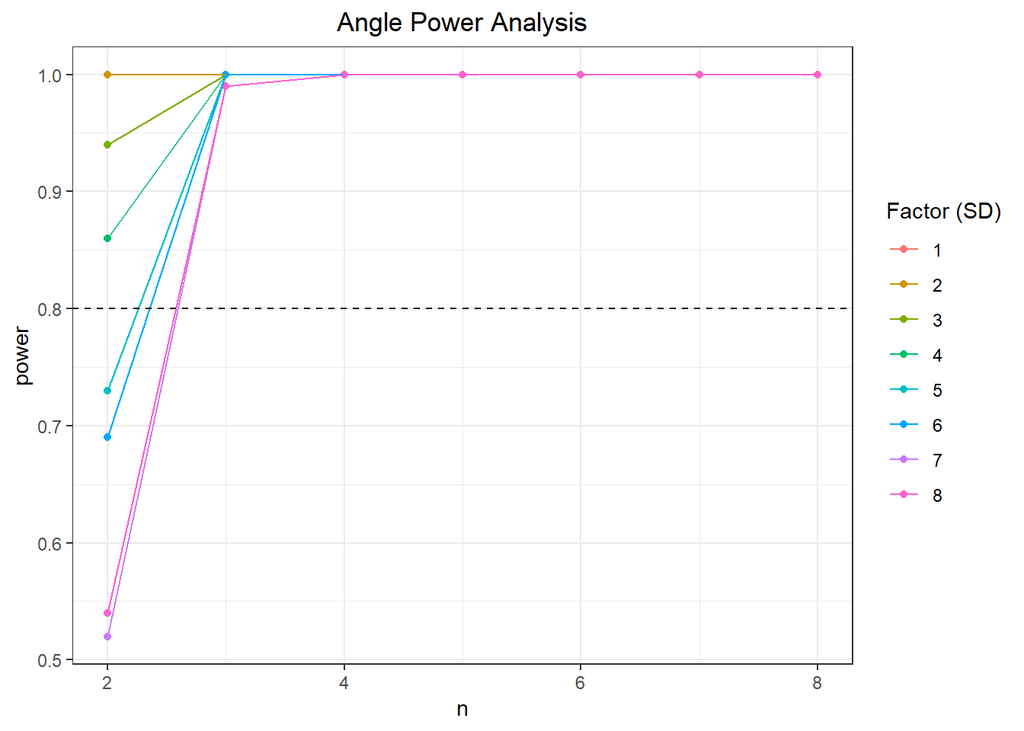

```r
#lower power with smaller sample size, just over 0.8

#get power from simulations
angle_power <- crossing(m1 = mean_angle_Y, m2 = mean_angle_N, s = 1:8, n = 2:8) %>%
  rowwise() %>%
  mutate(power = get_t_power(m1, m2, s, n, nsim = 100)) %>%
  ungroup()

ggplot(angle_power,
       mapping = aes(x = n, y = power, color = factor(s))) +
  geom_point() +
  geom_line() +
  theme_bw() +
  geom_hline(yintercept = 0.8, lty =2) +
  ggtitle("Angle Power Analysis") +
  theme(plot.title = element_text(hjust = 0.5)) +
  labs(colour = "Factor (SD)")
```

```r
#this shows that sample size of at least 3 would have enough power for angle data - because the mean_angle_N is basically 0.
```

##### Figure 18: Power analysis of Angle data. This shows that sample size of at least 3 will have enough power to reach the threshold of 0.8, with SD’s ranging from 1:8.

```r
###Time Power

#testing out extracton function:
get_p_from_t_test(make_t_data(m1 = mean_time_Y, m2 = mean_time_N, s = sd_time_Y, n = 100))
```

```
## [1] 0.4796852
```

```r
#no significant p value (as expected)
get_p_from_t_test(make_t_data(m1 = mean_time_Y, m2 = mean_time_N, s = sd_time_Y, n = 3))
```

```
## [1] 0.8488812
```

```r
#no significant p value (as expected)

#test the power function

get_t_power(m1 = mean_time_Y, m2 = mean_time_N, s = sd_time_Y, n = 100, nsims = 100, alpha=0.05)
```

```
## [1] 0.11
```

```r
#higher power with bigger sample size
get_t_power(m1 = mean_time_Y, m2 = mean_time_N, s = sd_time_Y, n = 3, nsims = 100, alpha=0.05)
```

```
## [1] 0.02
```

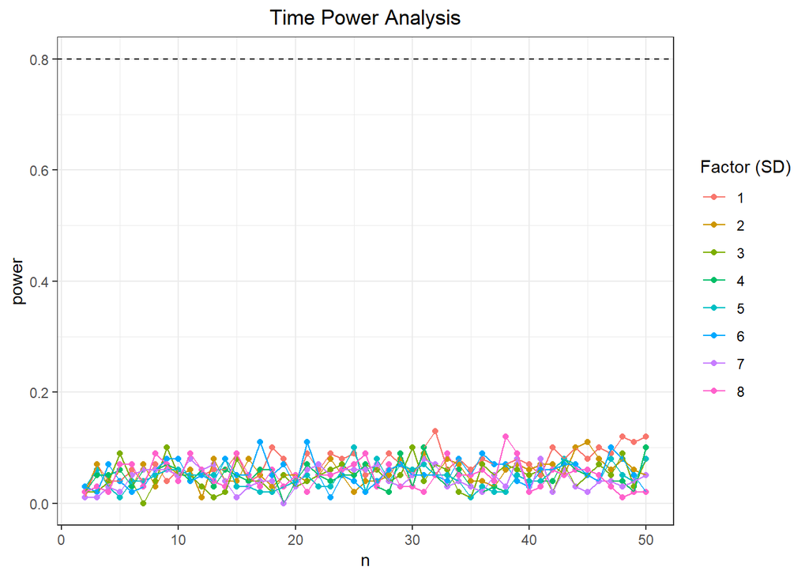

```r
#lower power with smaller sample size, just over 0.8

#get power from simulations
time_power <- crossing(m1 = mean_time_Y, m2 = mean_time_N, s = 1:8, n = 2:50) %>%
  rowwise() %>%
  mutate(power = get_t_power(m1, m2, s, n, nsim = 100)) %>%
  ungroup()

ggplot(time_power,
       mapping = aes(x = n, y = power, color = factor(s))) +
  geom_point() +
  geom_line() +
  theme_bw() +
  geom_hline(yintercept = 0.8, lty =2) +
  ggtitle("Time Power Analysis") +
  theme(plot.title = element_text(hjust = 0.5)) +
  labs(colour = "Factor (SD)")
```

```r
#since there is no simulated difference between the time means, not being able to reach a power threshold is expected
```

##### Figure 19: Power analysis of Time data. As there is no significant difference between the two means, the power threshold of 0.8 will not be able to be met.

# DISCUSSION

#### According to the power analyses, significant results of the Welch two-sample t-tests can be achieved with relatively small sample sizes, assuming that real-time data follows trends that were simulated. Real-time AIS data will be processed for this study for future analysis. When real-time AIS data are obtained, I will most likely have uneven sample sizes, so statistical testing will need to account for that (a Welch two-sample t-test accounts for unequal variances, so would still be appropriate). Normality of the real-time data will also need to be investigated and tested, in order to meet assumptions for the Welch two-sample t-test. If the normal distribution assumption of the real-time data cannot be met, a Mann-Whitney U-test would be used in its place, as it can be used to compare two means with non-normal distribution (Whitlock & Schluter 2015).

#### When analyzing real-time AIS data, the predictors will need to be tested to see if they are actually independent of each other. Plots comparing predictors can be used as they were in the initial visualizations shown in Figure 3. If all or some predictors appear dependent of each other, ANOVA statistical tests could be used to investigate potential covariance.

#### Finally, to do determine a true “control” group, I will need to see if there are other reasons that ships might deviate from their track other than if whale watch boats via AIS. When whale watch boats are not shown to be present on AIS, I will sub-sample some control days to see how often tracks deviate from their track and/or change velocity. To further confirm a true “control”, I will use my multi-year whale watch database with Boston Harbor Cruises to additionally confirm whether whale watch boats were present (and not reporting location via AIS). Using this data, I can see if ships also deviate tracks when non-AIS reporting whale watch boats are present.

# REFERENCES

#### Davis, G.E., Baumgartner, M.F., Bonnell, J.M., Bell, J., Berchok, C., Thornton, J.B., Brault, S.,Buchanan, G., Charif, R.A., Cholewiak, D. and Clark, C.W., 2017. Long-term passive acoustic recordings track the changing distribution of North Atlantic right whales (Eubalaena glacialis) from 2004 to 2014. Scientific Reports, 7(1), p.13460.

#### Federal Register (2003) Automatic Identification System; vessel carriage requirement. Coast Guard, U.S. Department of Homeland Security, 60559-60570. October 22.

#### International Association of Marine Aids to Navigation and Lighthouse Authorities (IALA) (2004) IALA Guideline No. 1028 on the Automatic Identification System (AIS): Part I. Operational issues. 1. Saint Germain en Laye, France.

#### Nowacek, D.P., M.P. Johnson, and P.L. Tyack. 2004. North Atlantic right whales (Eubalaena glacialis) ignore ships but respond to alerting stimuli. Proceedings of the Royal Society of London B: Biological Sciences 271:227-231.

#### Thomas, P.O., R.R. Reeves, and R.L. Brownell. 2016. Status of the world’s baleen whales. Marine Mammal Science 32:682-734.

#### Van Der Hoop, J.M., M.J. Moore, S.G. Barco, T.V. Cole, P.Y. Daoust, A.G. Henry, D.F. McAlpine, W.A. McLellan, T. Wimmer, and A.R. Solow. 2013. Assessment of management to mitigate anthropogenic effects on large whales. Conservation Biology 27:121-133.

#### Whitlock, M & D. Schluter. 2015. Roberts and Company Publishers. Greenwood Village, CO.

#### Wiley, D.N, L. Hatch, M. Thompson, K. Schwehr, and C. MacDonald. 2013. Marine Sanctuaries and Marine Planning: Protecting endangered marine life. National Ocean Policy. Proceedings Fall 2013:10-15. www.uscg.mil/proceedings